# Ferdous Faculty Applications: 2023

School specific application materials with deadlines.

Md Ferdous Alam https://ferdous-alam.github.io (PhD candidate, Hoelzle Research Lab, MAE, The Ohio State University)https://mae.osu.edu  
10-23-2022

> *NOTE:* Most updated generic application materials (CV, research statement, teaching statement, diversity statement) can be found [here](https://drive.google.com/drive/folders/15JN0V_O5szYkRlhoUra7-2kI_ejop3Yr?usp=sharing). School specific materials can be found below.

University

Topic

Deadline

Remarks

Link

Status

Materials

1

NC State (ISE)

next gen Mfg, robotics

Nov 1/open

-

[Link](https://connect.informs.org/HigherLogic/System/DownloadDocumentFile.ashx?DocumentFileKey=b32aac71-68cb-4d6c-856d-b19d859163b4)

submitted

2

NC State (ME)

next gen Mfg, robotics

Nov 1/open

-

[Link](https://jobs.ncsu.edu/postings/171488)

submitted

3

UT Austin (ME)

Mfg, Control, robotics

Nov 1

-

[Link](https://www.me.utexas.edu/people/faculty-jobs)

submitted

4

Carnegie Mellon (ME)

Control, robotics, AI/ML

Nov 1

-

[Link](https://www.meche.engineering.cmu.edu/employment.html)

submitted

5

Arizona State (ME)

Control, Autonomous, robotics

Nov 5

-

[Link](https://apply.interfolio.com/113817)

submitted

6

SUNNY Binghamton (SSIE)

Autonomous systems

rolling

-

Link

submitted

7

Northwestern (ME)

Mfg, data analytics, Mfg optiization

Nov 15

-

[Link](https://www.mccormick.northwestern.edu/mechanical/careers/)

submitted

8

Wichita State (ME)

AI, robotics, Mfg

Nov 15

-

[Link](https://jobs.wichita.edu/postings/27298)

submitted

9

Ottawa (ME) CAN

AI/ML, autonomous, robotics

Nov 15

-

[Link](https://uottawa.njoyn.com/CL3/xweb/Xweb.asp?tbtoken=ZltZRh5QRlU4Ygd2MSMnYVpUeWRdcUxYelBWTikEf2xFWUEdXEYdcxMHdkFcGVtXTnViXzpQ&chk=ZVpaShI%3D&CLID=57566&page=jobdetails&JobID=J1022-0837&lang=1)

submitted

10

Notre Dame (ME)

Robotics, Mfg, Data Sci

Nov 4/Dec 1

-

[Link](https://apply.interfolio.com/112134)

submitted

11

Oregon State (ME)

Mfg, Control, AI, robotics, mechatronics

Dec 1

-

[Link](https://jobs.oregonstate.edu/postings/125513)

submitted

12

UC Merced (ME)

AI/ML, Mfg

Dec 1

-

[Link](https://aprecruit.ucmerced.edu/JPf01419)

submitted

13

Santa Clara (ME)

Design, Mfg, Robotics, Control

Dec 2

-

[Link](https://wd1.myworkdaysite.com/en-US/recruiting/scu/scu/job/Santa-Clara-CA/Assistant-Professor-of-Mechanical-Engineering_R2846)

submitted

14

UC Irvine (ME)

Autonomous systems, Desin and Mfg, Robotics

Dec 11

-

[Link](https://recruit.ap.uci.edu/JPF07842)

submitted

15

Uni of Maryland (ME)

AI/ML, manufacturing

Dec 15

-

[Link](https://ejobs.umd.edu/postings/100313)

submitted

16

Rensselaer (ME)

AI/ML, robotics, Mfg

rolling

-

[Link](https://careers.rpi.edu/cw/en-us/job/493546/assistant-or-associate-professor-mechanical-engineering)

submitted

17

Rice (ME)

Autonomous systems, Desin and Mfg, Robotics

Dec 31

-

[Link](https://apply.interfolio.com/114276)

submitted

18

UT Dallas (ME)

Design, Mfg, Automation, robotics

Dec 31

Justin Koeln

[Link](https://jobs.utdallas.edu/postings/20919)

submitted

19

Binghampton (ME)

Mfg, AI, autonomy

Dec 31

-

[Link](https://binghamton.interviewexchange.com/jobofferdetails.jsp;jsessionid=C26E16D6051D3EE42EE4C2EF78BBA434?JOBID=155524)

submitted

20

Uni Dayton (ME)

AI/ML, Design, Mfg

Jan 03

-

[Link](https://employment.udayton.edu/cw/en-us/job/500487/assistant-professor-specializing-in-design-andor-manufacturing-department-of-mechanical-and-aerospace-engineering)

submitted

21

New Hapshire (ME)

AI/ML, control/robotics, Mfg

Dec 15

-

[Link](https://jobs.usnh.edu/postings/52307)

submitted

22

Stevens IT (ME)

AI/ML, Design, robotics, Mfg

rolling

-

[Link](https://stevens.wd5.myworkdayjobs.com/External/job/Hoboken-NJ---Main-Campus/Assistant-Associate-Professor--Mechanical-Engineering_RQ26335)

submitted

23

Southern_Illinois_carbondale (ME)

Control, ML, robotics, Mfg

Jan 5

-

[Link](https://jobs.siu.edu/staff/job-details-staff?jobID=14494&job=assistant-professor-mechanical-engineering)

submitted

24

UW Madison (ME)

Autonomous systems, Mfg, Learning

Jan 12

-

[Link](https://jobs.hr.wisc.edu/en-us/job/515799/assistant-professor)

submitted

25

Rutgers (ME)

AI/ML, robotics, Mfg

rolling

-

[Link](https://jobs.rutgers.edu/postings/182123)

$\sim$

26

Pitts (ME)

AI/ML, robotics, Mfg

rolling

-

[Link](https://lsu.wd1.myworkdayjobs.com/en-US/LSU/job/Assistant-Professors--Tenure-Track----Mechanical-and-Industrial-Engineering_R00074381)

$\sim$

27

Arizona State (ME)

Machine Leanring for ME

Nov 27

-

[Link](https://apply.interfolio.com/115629)

$\sim$

28

Oklahoma State (ME)

AI/ML, robotics, Mfg

Dec 1

-

[Link](https://okstate.csod.com/ats/careersite/JobDetails.aspx?site=8&id=12429)

$\sim$

29

University of Cincinnati (ISE)

Mfg, data analytics, Cyber-physical

rolling

-

[Link](https://drive.google.com/drive/folders/1iNd8JOW1k3LrbfLAyUf08beWS0UdULjH?usp=sharing)

$\sim$

30

U Alabama (ME)

AI/ML, robotics, Mfg

rolling

-

[Link](https://jobs.rutgers.edu/postings/186225)

$\sim$

31

Louisiana State (ME)

AI/ML, robotics, Mfg

rolling

-

[Link](https://lsu.wd1.myworkdayjobs.com/en-US/LSU/job/Assistant-Professors--Tenure-Track----Mechanical-and-Industrial-Engineering_R00074381)

$\sim$

32

Texas State (ME)

AI/ML, Mfg

Jan 10

-

[Link](https://jobs.hr.txstate.edu/postings/40240)

$\sim$

33

NJIT (MIE)

AI/ML, design, Mfg, robotics

rolling

-

[Link](https://njit.csod.com/ux/ats/careersite/1/home/requisition/4537?c=njit)

$\sim$

34

Queen’s (ECE) CAN

AI/ML, autonomous, robotics

Jan 15

-

[Link](https://www.ece.queensu.ca/about-us/IBENG212201_ECE_MRE_Sept-2022.pdf)

$\sim$

35

UMass Lowell (ME)

robotics

Jan 15

-

[Link](https://explorejobs.uml.edu/mob/lowell/en-us/job/516984/tenuretrack-assistant-professor-robotics-mechanical-engineering)

$\sim$

36

U Arizona (ME)

robotics/autonomous

Jan 17

-

[Link](https://arizona.csod.com/ux/ats/careersite/4/home/requisition/12635?c=arizona)

$\sim$

37

UMich (ME)

Control, Mfg

Jan 31

-

[Link](https://me.engin.umich.edu/about/positions/faculty/)

$\sim$

### Ferdous past research and future research plans:

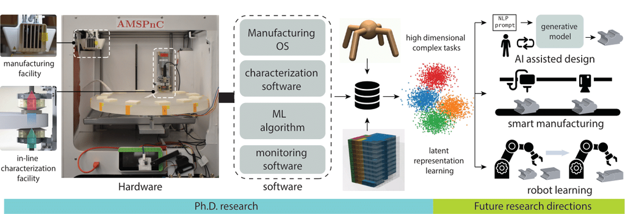

### PostDoc applications:

University

Topic

Deadline

Remarks

Link

Status

Materials

1

MIT (ME)

AI for engineering Design

open

Faez Ahmed

[Link](https://careers.peopleclick.com/careerscp/client_mit/external/en-us/gateway/viewFromLink.html?jobPostId=25495&localeCode=en-us)

submitted

2

UT Austin (ECE)

RL, robotics

open

Amy Zhang/Peter Stone

[Link](https://ml.utexas.edu/postdoctoral-positions)

submitted

3

PNNL

RL, Sci ML

Nov 8

-

[Link](https://careers.pnnl.gov/jobs/5695?lang=en-us)

submitted

4

Argonne NL

ML, optimal control

open

-

[Link](https://argonne.wd1.myworkdayjobs.com/en-US/Argonne_Careers/job/Lemont-IL-USA/Postdoctoral-Appointee--Optimization-and-Mathematics-for-Digital-Twins_414375)

$\sim$

5

CMU robotics

robotics, Deep learning

Not specified

-

[Link](https://cmu.wd5.myworkdayjobs.com/en-US/CMU/job/Pittsburgh-PA/Postdoctoral-Fellow--Robotics-Institute_2018951?source=HigherEdJobs)

$\sim$